# Assignment 1

David Krütli, Serhat Nergiz, Ibrahim Yaman, Mohamed Ramadan

2023-11-21 19:53:55.417368

##To Do: By Thursday - Variable for Exploration: creditData - Variable for Processing: creditDataProcessed

By Thursday morning - Correlation matrix - Multicollinearity

# Business Understanding

# Setup

## Load Required Packages

First of all we are going to load the packages required for this project.

```r
#install.packages("readr")
#install.packages("tidyverse")
#install.packages("formattable")
#install.packages("car")
#install.packages("corrplot")
#install.packages("dbplyr")
#install.packages("formattable")
#install.packages("Hmisc")
#install.packages("lmtest")
#install.packages("openxlsx")

library(car)
library(corrplot)
library(dbplyr)
library(formattable)
library(Hmisc)
library(lmtest)
library(openxlsx)
library(readr)
library(tidyverse)
```

## Load Data

Next we are going to load the data from the CSV file “LCdata.csv” and display the first row to get a rough idea about the data.

```r
creditData <- read_delim("/Users/serhat/Downloads/LCdata.csv", delim = ";", escape_double = FALSE, trim_ws = TRUE)
knitr::kable(head(creditData, 1))
```

| id | member_id | loan_amnt | funded_amnt | funded_amnt_inv | term | int_rate | installment | emp_title | emp_length | home_ownership | annual_inc | verification_status | issue_d | loan_status | pymnt_plan | url | desc | purpose | title | zip_code | addr_state | dti | delinq_2yrs | earliest_cr_line | inq_last_6mths | mths_since_last_delinq | mths_since_last_record | open_acc | pub_rec | … |
| --- | --- | --- | --- | --- | --- | --- | --- | --- | --- | --- | --- | --- | --- | --- | --- | --- | --- | --- | --- | --- | --- | --- | --- | --- | --- | --- | --- | --- | --- | --- |
| 83489 | 83471 | 2600 | 2600 | 575 | 36 months | 8.38 | 81.94 | College Pro Painters | 3 years | MORTGAGE | 6500 | Not Verified | Jun-2007 | Does not meet the credit policy. Status:Charged Off | n | https://www.lendingclub.com/browse/loanDetail.action?loan_id=83489 | I would like to refinance my credit card debt to recieve a better rate on the money I owe. | other | Credit card refinancing | 806xx | CO | 6.46 | NA | NA | NA | NA | NA | NA | NA | … |

## Structure of the Dataset

The dataset has **798641** rows and **72** columns.

## Data removal

The decision to drop certain variables from the dataset for predicting the interest rate of new loan applications is based on their unavailability or irrelevance at the time of prediction. First of all we are going to drop these variables:

```r
creditData2 <- subset(creditData,select=-c(collection_recovery_fee,
                                                       installment,
                                                       issue_d,
                                                       last_pymnt_amnt,
                                                       last_pymnt_d,
                                                       loan_status,
                                                       next_pymnt_d,
                                                       out_prncp,
                                                       out_prncp_inv,
                                                       pymnt_plan,
                                                       recoveries,
                                                       term,
                                                       total_pymnt,
                                                       total_pymnt_inv,
                                                       total_rec_int,
                                                       total_rec_late_fee,
                                                       total_rec_prncp))
```

Next we are removing all variables with more than 200’000 blank values.

```r
creditData3<- subset(creditData2,select=-c(annual_inc_joint,
                                                       desc,
                                                       dti_joint,
                                                       mths_since_last_delinq,
                                                       mths_since_last_major_derog,
                                                       mths_since_last_record,
                                                       open_acc_6m,
                                                       open_il_6m,
                                                       open_il_12m,
                                                       open_il_24m,
                                                       mths_since_rcnt_il,
                                                       total_bal_il,
                                                       il_util,
                                                       open_rv_12m,
                                                       open_rv_24m,
                                                       max_bal_bc,
                                                       all_util,
                                                       total_rev_hi_lim,
                                                       inq_fi,
                                                       total_cu_tl,
                                                       inq_last_12m))
```

We will also drop the variable url because with 798641 levels it is not going to say anything about our data. The policy code is also not really useful to predict the interest rate, because it only has the numeric value 1. Furthermore, the variable verified_status_joint will be dropped since there are only NA’s in there.

```r
creditData4<- subset(creditData3,select=-c(policy_code,url,verification_status_joint))
```

# Explore Data

## Attribute revol_util

Display a summary of the attribute **revol_util**

```r
summary(creditData4$revol_util)
```

```
##    Min. 1st Qu.  Median    Mean 3rd Qu.    Max.    NA's
##    0.00   37.70   56.00   55.05   73.50  892.30     454
```

As we can see, this attribute has 454 blanks which we are going to remove entirely from the dataset.

```r
creditData5 <- filter(creditData4, ! is.na(revol_util))
```

We should also check if there are any outliers:

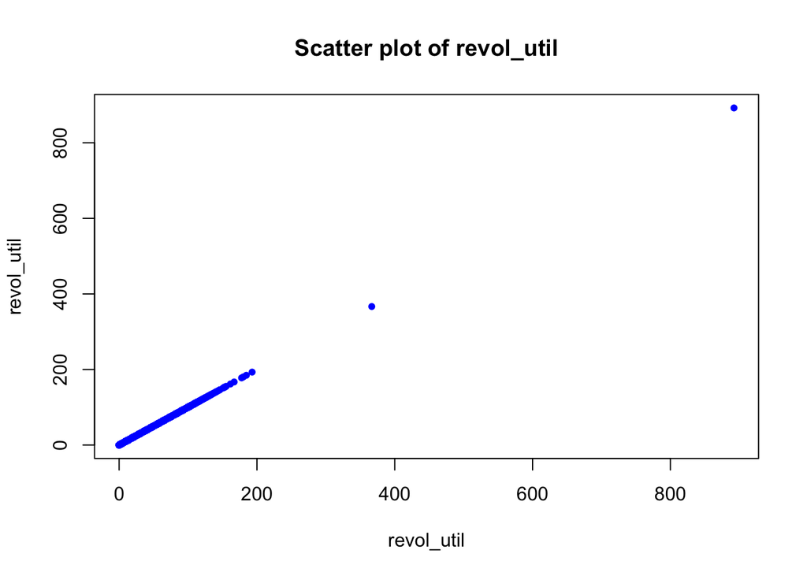

```r
plot(creditData5$revol_util, creditData5$revol_util,
     xlab = "revol_util",
     ylab = "revol_util",
     main = "Scatter plot of revol_util",
     pch = 20,
     col = "blue")
```

```r
creditData5 <- subset(creditData5, revol_util <= 200)
```

## Attribute title

```r
summary(creditData5$title)
```

```
##    Length     Class      Mode
##    798185 character character
```

It is visible, that we have 56143 levels and this is way to much. Let’s see which of them are occuring the most.

```r
max(table(creditData5$title))
```

```
## [1] 372921
```

```r
FrequencyTitle <- round(prop.table(table(creditData5$title))*100,2)
table <- cbind(FrequencyTitle)
```

```r
category_frequency <- table(creditData5$title)
sorted_frequency <- sort(category_frequency, decreasing = TRUE)
top30 <- head(sorted_frequency, 30)
top30_namen <- names(top30)
creditData5$title <- ifelse(creditData5$title %in% top30_namen, creditData5$title, 'others')
```

Now we can see which categories are left:

```r
table(creditData5$title)
```

```
##
##                  Business             Car financing               consolidate
##                      6077                      4962                       703
##               Consolidate             consolidation             Consolidation
##                      1203                      2049                      5154
##        Consolidation Loan Credit Card Consolidation          Credit Card Loan
##                      1659                      2207                       708
##        Credit Card Payoff     Credit Card Refinance   Credit card refinancing
##                      1277                      1375                    147875
##                      Debt        debt consolidation        Debt consolidation
##                       750                      4549                    372921
##        Debt Consolidation   Debt Consolidation Loan                   Freedom
##                     14691                      3447                       746
##               Home buying          Home improvement          Home Improvement
##                      2113                     36043                      1686
##                      Loan            Major purchase          Medical expenses
##                       973                     10869                      5963
##     Moving and relocation                     Other                    others
##                      3508                     28718                    128670
##                  personal                  Personal             Personal Loan
##                       743                      1153                      1975
##                  Vacation
##                      3418
```

Finally, we can factorise this variable

```r
creditData5$title <- factor("title")
```

## Attribute zip_code

Let us first have a look at the variable:

```r
summary(creditData5$zip_code)
```

```
##    Length     Class      Mode
##    798185 character character
```

```r
head(creditData5$zip_code)
```

```
## [1] "068xx" "300xx" "633xx" "570xx" "325xx" "731xx"
```

Let’s have a more in depth view on the data:

```r
tab <- table(creditData5$zip_code, creditData5$addr_state)
```

As we can see with the table function, some of the zip_code are occuring in multiple states. Therefore, it makes sense to combine the zip_code and addr_state variable to create truely unique values. This way it could give us a better prediction for the interest rate.

```r
creditData5$zip_code <- substr(creditData5$zip_code, 1, 3)
creditData5$combo_zip_addr <- paste0(creditData5$zip_code, creditData5$addr_state)
#print(creditDataSerhat4)
creditData5 <- subset(creditData5,select=-c(zip_code,addr_state))
```

Finally, we can factorise this variable

```r
creditData5$combo_zip_addr <- factor("combo_zip_addr")
```

## Attribute acc_now_deling

Let us first have a look at the variable:

```r
summary(creditData5$acc_now_delinq)
```

```
##      Min.   1st Qu.    Median      Mean   3rd Qu.      Max.
##  0.000000  0.000000  0.000000  0.005025  0.000000 14.000000
```

More than 75% of the data seems to have the value 0. We can keep it as it is for further analysis. But we can check how many values are higher than zero to understand the data better.

```r
Higher0 <- sum(creditData5$acc_now_delinq > 0, na.rm = TRUE)
print(Higher0)
```

```
## [1] 3724
```

We should also check if there are any outliers:

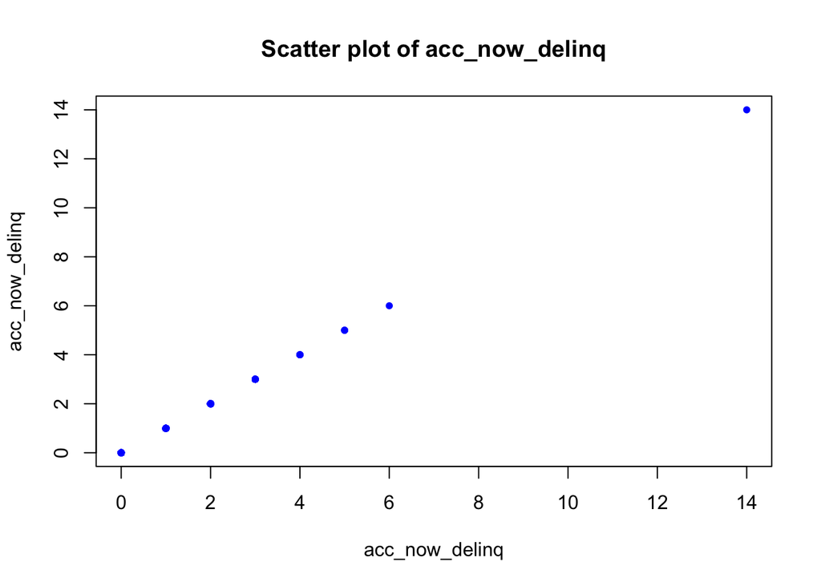

```r
plot(creditData5$acc_now_delinq, creditData5$acc_now_delinq,
     xlab = "acc_now_delinq",
     ylab = "acc_now_delinq",
     main = "Scatter plot of acc_now_delinq",
     pch = 20,
     col = "blue")
```

There doesn’t seem to have outrageous outliers, so we keep the data as it is.

## Attribute tot_coll_amt

Now we can have a look at the attribute tot_coll_amt.

```r
summary(creditData$tot_coll_amt)
```

```
##    Min. 1st Qu.  Median    Mean 3rd Qu.    Max.    NA's
##       0       0       0     228       0 9152545   63276
```

There are many NA’s with 63276 but we don’t want to drop the variable since it is less than 10% of the whole data set. Let’s see how many values are exactly 0.

```r
zero_in_column <- sum(creditData5$tot_coll_amt == 0, na.rm = TRUE)
print(zero_in_column)
```

```
## [1] 630266
```

```r
median_tot_coll_amt <- median(creditData5$tot_coll_amt, na.rm = TRUE)

creditData5$tot_coll_amt[is.na(creditData5$tot_coll_amt)] <- median_tot_coll_amt
```

We should also check if there are any outliers:

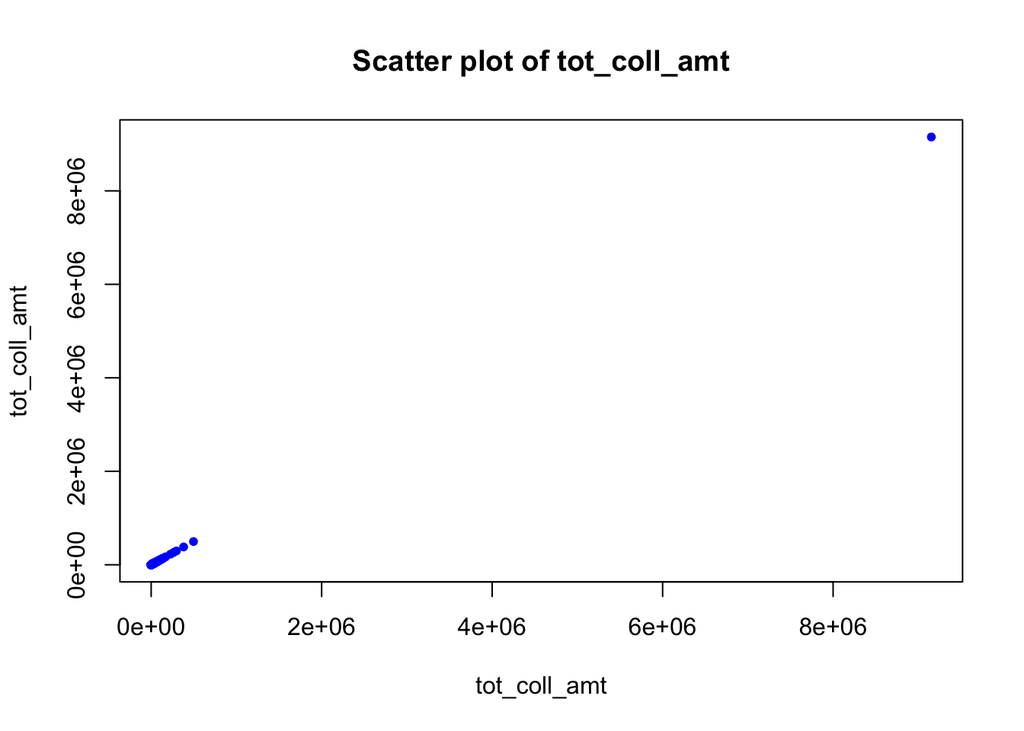

```r
plot(creditData5$tot_coll_amt, creditData5$tot_coll_amt,
     xlab = "tot_coll_amt",
     ylab = "tot_coll_amt",
     main = "Scatter plot of tot_coll_amt",
     pch = 20,
     col = "blue")
```

There is an outlier, so we are removing it.

```r
creditData5 <- subset(creditData5, tot_coll_amt <= 2000000)
```

## Attribute tot_cur_bal

Now we can have a look at the attribute tot_cur_bal.

```r
summary(creditData$tot_cur_bal)
```

```
##    Min. 1st Qu.  Median    Mean 3rd Qu.    Max.    NA's
##       0   29861   80647  139508  208229 8000078   63276
```

There are many NA’s with 63276 but we don’t want to drop the variable since it is less than 10% of the whole data set. Let’s see how many values are exactly 0.

```r
zero_in_column <- sum(creditData5$tot_cur_bal == 0, na.rm = TRUE)
print(zero_in_column)
```

```
## [1] 102
```

Only 102 cells with the value 0. It makes absolutely sense to replace this time the NA’s with the mean, which would be 139508. The distribution between the value seems also alright.

```r
mean_tot_cur_bal <- mean(creditData5$tot_cur_bal, na.rm = TRUE)

creditData5$tot_cur_bal[is.na(creditData5$tot_cur_bal)] <- mean_tot_cur_bal
```

We should also check if there are any outliers:

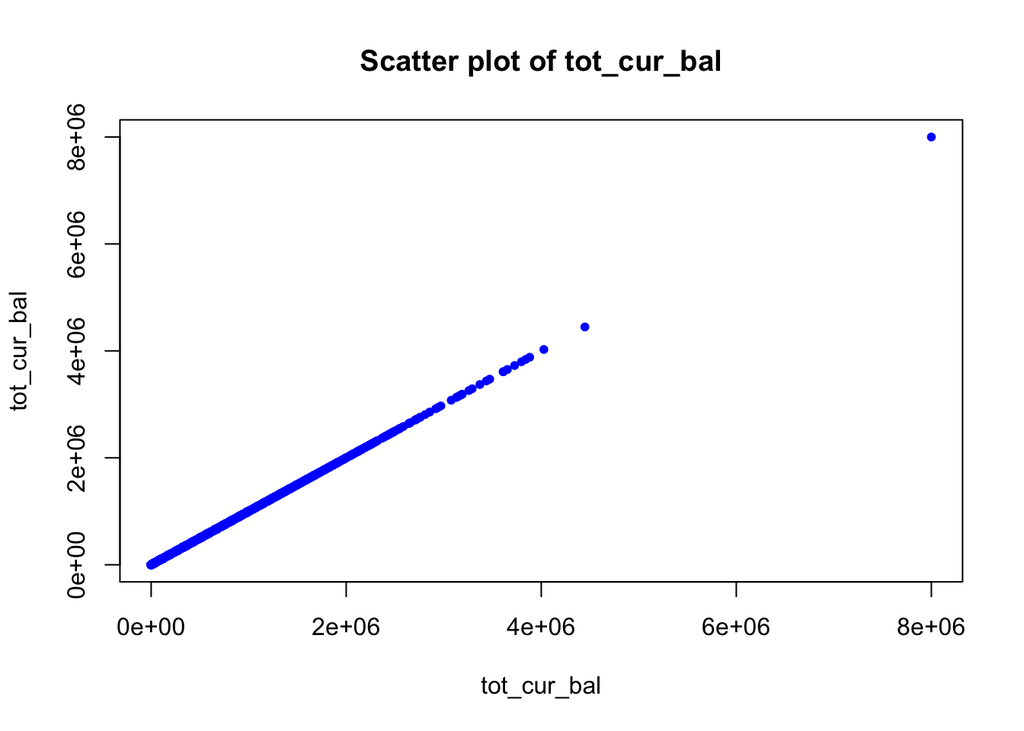

```r
plot(creditData5$tot_cur_bal, creditData5$tot_cur_bal,
     xlab = "tot_cur_bal",
     ylab = "tot_cur_bal",
     main = "Scatter plot of tot_cur_bal",
     pch = 20,
     col = "blue")
```

There is an outlier, so we are removing it.

```r
creditData5 <- subset(creditData5, tot_cur_bal <= 4000000)
```

## Attribute addr_state

Display a summary of the attribute **addr_state**:

```r
summary(creditData$addr_state)
```

```
##    Length     Class      Mode
##    798641 character character
```

Plot the distribution of the attribute **addr_state**:

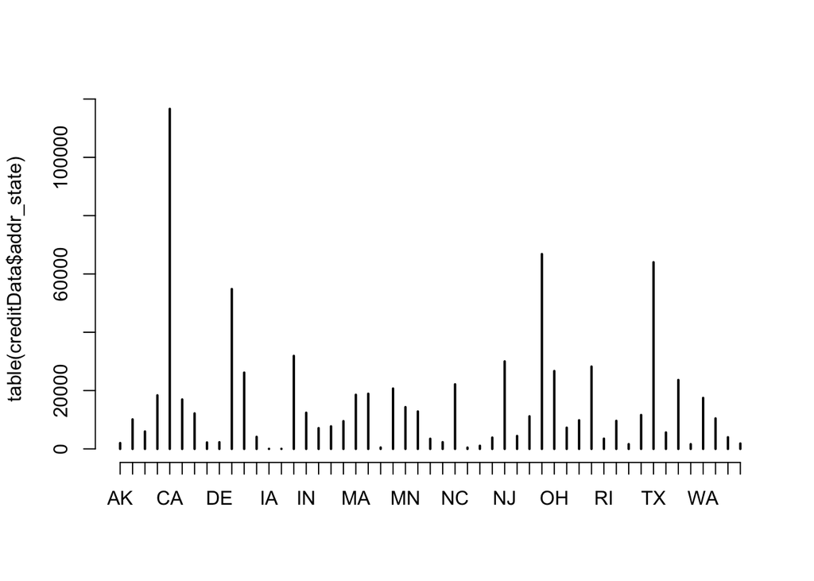

```r
plot(table(creditData$addr_state))
```

Build a contingency table of the counts at each combination of factor levels.

```r
table(creditData$addr_state)
```

```
##
##     AK     AL     AR     AZ     CA     CO     CT     DC     DE     FL     GA
##   1992  10101   5955  18362 116619  16940  12155   2194   2268  54824  26154
##     HI     IA     ID     IL     IN     KS     KY     LA     MA     MD     ME
##   4113     14     11  31885  12393   7110   7727   9500  18552  18908    469
##     MI     MN     MO     MS     MT     NC     ND     NE     NH     NJ     NM
##  20681  14310  12823   3457   2288  22138    431   1064   3865  30001   4429
##     NV     NY     OH     OK     OR     PA     RI     SC     SD     TN     TX
##  11158  66812  26687   7266   9809  28224   3500   9610   1616  11618  64003
##     UT     VA     VT     WA     WI     WV     WY
##   5631  23624   1607  17477  10447   3978   1841
```

**Conclusion**:

We should keep this attribute in the dataset for the moment. The interest rate could depend on the area where the borrower lives. This attribute needs to be converted into a categorical value (factor).

Convert the character attribute into a categorical value (factor):

```r
creditData$addr_state <- as.factor(creditData$addr_state)
str(creditData$addr_state)
```

```
##  Factor w/ 51 levels "AK","AL","AR",..: 6 35 35 17 35 35 7 11 25 42 ...
```

## Attribute annual_inc

Display a summary of the attribute **annual_inc**:

```r
summary(creditData$annual_inc)
```

```
##    Min. 1st Qu.  Median    Mean 3rd Qu.    Max.    NA's
##       0   45000   65000   75014   90000 9500000       4
```

Plot a historgram for **annual_inc**, where the annual income is higher than 500’000:

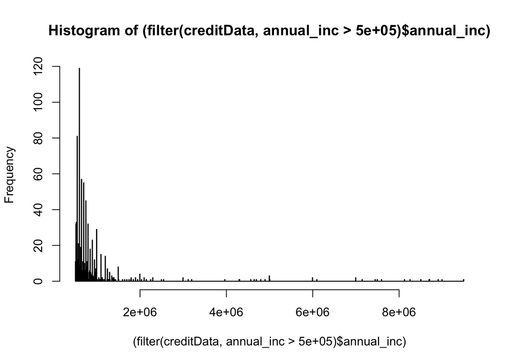

```r
hist((filter(creditData, annual_inc > 500000)$annual_inc), breaks = 1000)
```

As can be seen in the histogram, there are a few very high values, so we want to see if these are errors in our dataset. Therefore we are going to list the **emp_title** and **verification_status** for the top 50 values.

```r
select(head(creditData[order(creditData$annual_inc, decreasing = TRUE), ], 50), annual_inc, emp_title, verification_status)
```

```
## # A tibble: 50 × 3
##    annual_inc emp_title                           verification_status
##         <dbl> <chr>                               <chr>
##  1    9500000 reg nurse                           Source Verified
##  2    9000000 registered nurse                    Source Verified
##  3    8900060 commercial driver                   Source Verified
##  4    8706582 Correctional Sgt.                   Source Verified
##  5    8700000 Customer Representative             Source Verified
##  6    8500021 Senior Field Operator               Source Verified
##  7    8253000 Sr Mgr                              Source Verified
##  8    8121180 Facilities Operations Manager       Source Verified
##  9    7600000 Interim Director of Case Management Source Verified
## 10    7500000 Sales & service rep                 Verified
## # ℹ 40 more rows
```

Looks like there are indeed some unrealistic values in our dataset: A nurse with an annual income of USD 9.5 million or a commercial driver with USD 8.9 million seems to be way above the expected income, although source was verified.

**Conclusion**:

We should keep this attribute in the dataset for the moment. The interest rate would probably depend on the borrower’s annual income, as this tells us something about the borrower’s creditworthiness. The 4 records with NA for the annual income should be removed. We should also consider filling the values above a certain threshold (e.g. 800’000) with the median (i.e., 65’000).

Remove NAs and overwrite values > 800’000 with 65’000:

```r
creditData <- subset(creditData, is.na(creditData$annual_inc) != 1)
creditData$annual_inc <- if_else(creditData$annual_inc > 800000, 65000, creditData$annual_inc)
```

## Attribute application_type

Display a summary of the attribute **application_type**:

```r
summary(creditData$application_type)
```

```
##    Length     Class      Mode
##    798637 character character
```

Plot the distribution of the attribute **application_type**:

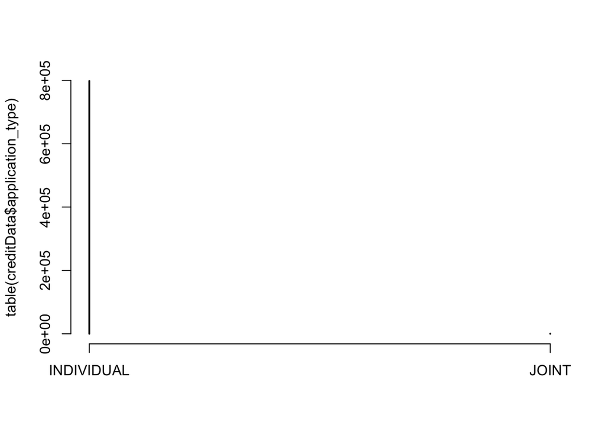

```r
plot(table(creditData$application_type))
```

Build a contingency table of the counts at each combination of factor levels.

```r
table(creditData$application_type)
```

```
##
## INDIVIDUAL      JOINT
##     798177        460
```

**Conclusion**:

Converting attribute into factor:

```r
creditData$application_type <- as.factor(creditData$application_type)
str(creditData$application_type)
```

```
##  Factor w/ 2 levels "INDIVIDUAL","JOINT": 1 1 1 1 1 1 1 1 1 1 ...
```

## Attribute verification_status

Display a summary of the attribute **verification_status**:

```r
count(creditData[is.na(creditData$verification_status), ])
```

```
## # A tibble: 1 × 1
##       n
##   <int>
## 1     0
```

```r
class(creditData$verification_status)
```

```
## [1] "character"
```

Factorize the character value

```r
vec_Verif <- as.factor(creditData$verification_status)
class(vec_Verif)
```

```
## [1] "factor"
```

## Attribute open_acc

Display the attribute open_acc

```r
summary(creditData$open_acc)
```

```
##    Min. 1st Qu.  Median    Mean 3rd Qu.    Max.    NA's
##    0.00    8.00   11.00   11.55   14.00   90.00      21
```

Display the class of the attribute open_acc:

```r
class(creditData$open_acc)
```

```
## [1] "numeric"
```

Assign the median value into the NAs

```r
med_open_acc <- median(creditData$open_acc, na.rm = TRUE)
med_open_acc
```

```
## [1] 11
```

```r
creditData[is.na(creditData$open_acc), "open_acc"] <- med_open_acc
```

## Attribute last_credit_pull_d

```r
unique(creditData$last_credit_pull_d)
```

```
##   [1] "Mar-2010" "Jun-2010" "May-2007" "Aug-2015" "Mar-2014" "Jan-2016"
##   [7] "Apr-2015" "Jan-2015" "Nov-2014" "Dec-2012" "Feb-2015" "Apr-2014"
##  [13] "Dec-2015" "Mar-2012" "Dec-2014" "Jun-2015" "Aug-2013" "Oct-2010"
##  [19] "Aug-2012" "Nov-2012" "Jun-2007" "Sep-2014" "Oct-2013" "Jun-2013"
##  [25] "Dec-2013" "Feb-2012" "Jan-2012" "May-2013" "Jul-2014" "May-2014"
##  [31] "Feb-2013" "Sep-2015" "Oct-2015" "Dec-2011" "Apr-2012" "Nov-2013"
##  [37] "Oct-2014" "Mar-2013" "May-2012" "May-2015" "Jun-2014" "Nov-2015"
##  [43] "Aug-2014" "Jul-2015" "Sep-2013" "Mar-2015" "Jul-2011" "Nov-2011"
##  [49] "Feb-2014" "Oct-2011" "Aug-2011" "May-2010" "Jan-2010" "Jun-2009"
##  [55] "Jun-2012" "Jul-2012" "Jun-2011" "Apr-2013" "Jul-2013" "Jan-2014"
##  [61] "Feb-2011" "Oct-2012" "Dec-2010" "Sep-2012" "Jul-2010" "Nov-2010"
##  [67] "Feb-2010" "Dec-2007" "Aug-2009" "Apr-2011" "Mar-2011" "Jan-2013"
##  [73] "May-2011" "Aug-2010" "Jan-2011" "Aug-2008" "Sep-2011" "Jul-2009"
##  [79] "Apr-2010" "Feb-2009" "Sep-2007" NA         "Jan-2009" "Dec-2009"
##  [85] "Oct-2009" "May-2009" "Aug-2007" "Sep-2010" "Sep-2009" "Mar-2008"
##  [91] "Dec-2008" "Oct-2008" "Nov-2009" "Mar-2009" "Apr-2009" "Feb-2008"
##  [97] "Sep-2008" "Oct-2007" "Nov-2007" "Jan-2008" "Jun-2008" "May-2008"
## [103] "Jul-2007"
```

Display the class

```r
class(creditData$last_credit_pull_d)
```

```
## [1] "character"
```

Factorize the attribute last_credit_pull_d

```r
vec_last_credit_pull_d <- as.factor(creditData$last_credit_pull_d)
class(vec_last_credit_pull_d)
```

```
## [1] "factor"
```

Remove the blanks

```r
creditData <- creditData[!is.na(creditData$last_credit_pull_d), ]
creditData
```

```
## # A tibble: 798,592 × 72
##          id member_id loan_amnt funded_amnt funded_amnt_inv term      int_rate
##       <dbl>     <dbl>     <dbl>       <dbl>           <dbl> <chr>        <dbl>
##  1    83489     83471      2600        2600             575 36 months     8.38
##  2    77792     77764      3000        3000             125 36 months     9.01
##  3    72176     70868      2525        2525             225 36 months     9.33
##  4    72819     72816      7200        5075             350 36 months    10.3
##  5    89258     80039      2000        2000            1275 36 months     7.12
##  6  5764263   7196024     18000       18000           18000 36 months     8.9
##  7   837813   1047868      5000        5000            5000 36 months     7.49
##  8 30585515  33138680      7000        7000            7000 36 months     6.49
##  9 29854965  32388141     15000       15000           15000 36 months     6.49
## 10  7699829   9401375     14500       14500           14500 36 months     7.62
## # ℹ 798,582 more rows
## # ℹ 65 more variables: installment <dbl>, emp_title <chr>, emp_length <chr>,
## #   home_ownership <chr>, annual_inc <dbl>, verification_status <chr>,
## #   issue_d <chr>, loan_status <chr>, pymnt_plan <chr>, url <chr>, desc <chr>,
## #   purpose <chr>, title <chr>, zip_code <chr>, addr_state <fct>, dti <dbl>,
## #   delinq_2yrs <dbl>, earliest_cr_line <chr>, inq_last_6mths <dbl>,
## #   mths_since_last_delinq <dbl>, mths_since_last_record <dbl>, …
```

## Attribute pub_rec

Assign the median into the missing values

```r
med_pub_rec <- median(creditData$pub_rec, na.rm = TRUE)
med_pub_rec
```

```
## [1] 0
```

```r
creditData[is.na(creditData$pub_rec), "pub_rec"] <- med_pub_rec
```

## Attribute purpose

Factorize the character

```r
vec_purpose <- as.factor(creditData$purpose)
class(vec_purpose)
```

```
## [1] "factor"
```

## Attribute collections_12_mths_ex_med

Display a summary of the attribute **collections_12_mths_ex_med**:

```r
summary(creditData$collections_12_mths_ex_med)
```

```
##     Min.  1st Qu.   Median     Mean  3rd Qu.     Max.     NA's
##  0.00000  0.00000  0.00000  0.01447  0.00000 20.00000      121
```

```r
table(creditData$collections_12_mths_ex_med)
```

```
##
##      0      1      2      3      4      5      6      7     10     14     16
## 787898   9797    662     79     21      7      2      1      1      1      1
##     20
##      1
```

```r
creditData <- subset(creditData, is.na(creditData$collections_12_mths_ex_med) != 1)
```

## Attribute delinq_2yrs

Display a summary for the atrribute **delinq_2yrs**

```r
summary(creditData$delinq_2yrs)
```

```
##    Min. 1st Qu.  Median    Mean 3rd Qu.    Max.
##  0.0000  0.0000  0.0000  0.3145  0.0000 39.0000
```

```r
table(creditData$delinq_2yrs)
```

```
##
##      0      1      2      3      4      5      6      7      8      9     10
## 645029 102015  30179  10789   4797   2439   1308    714    409    259    175
##     11     12     13     14     15     16     17     18     19     20     21
##    106     74     59     40     25     15      9     10      7      2      2
##     22     24     26     27     29     30     39
##      2      1      2      1      1      1      1
```

```r
creditData <- subset(creditData, is.na(creditData$delinq_2yrs) != 1)
```

## Attribute dti

Display a summary for the atrribute **dti**

```r
summary(creditData$dti)
```

```
##    Min. 1st Qu.  Median    Mean 3rd Qu.    Max.
##    0.00   11.91   17.66   18.16   23.95 9999.00
```

Probably some outliers in the data:

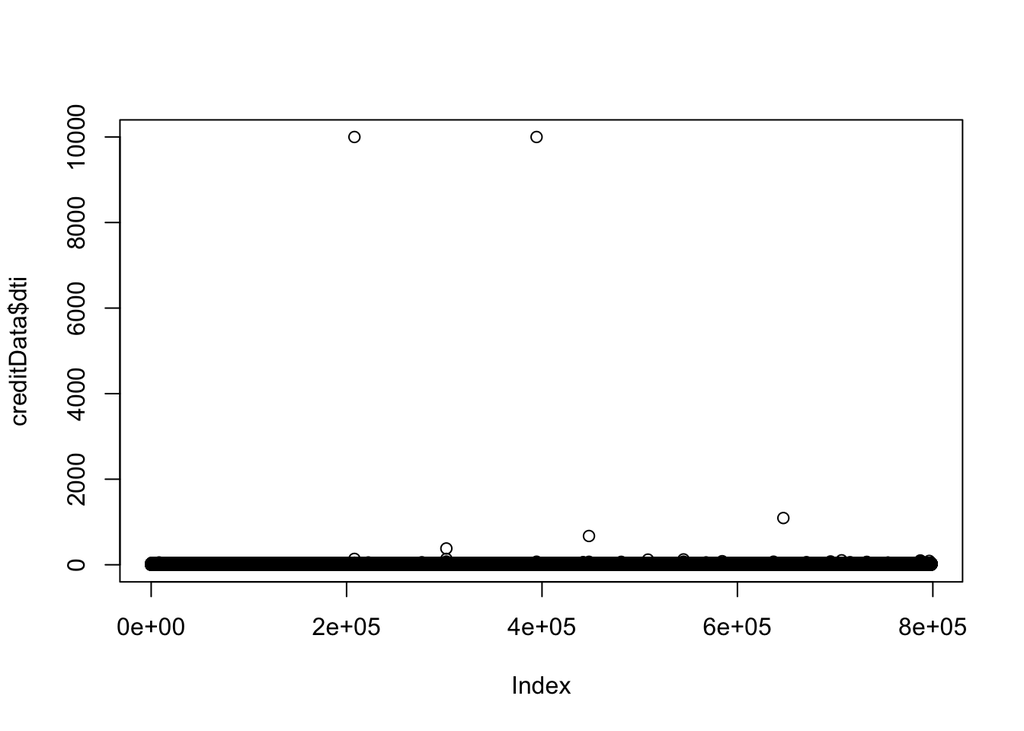

```r
plot(creditData$dti)
```

Let’s display the top 100 values for dti:

```r
head((creditData %>% arrange(desc(creditData$dti)))$dti, 100)
```

```
##   [1] 9999.00 9999.00 1092.52  672.52  380.53  137.40  136.97  125.25  120.66
##  [10]  104.00  100.09   90.00   89.83   83.64   83.40   77.06   74.48   72.30
##  [19]   71.82   71.40   69.35   68.41   67.50   64.99   63.64   61.21   60.08
##  [28]   59.26   59.26   59.18   58.54   57.14   55.10   55.06   54.36   54.19
##  [37]   54.10   52.80   52.45   51.20   48.91   48.56   48.48   47.61   47.31
##  [46]   47.06   46.92   46.92   46.89   46.71   46.67   46.28   46.28   45.78
##  [55]   45.58   45.32   44.89   44.86   44.52   44.43   44.33   44.24   44.22
##  [64]   44.09   43.98   43.68   43.49   42.64   42.37   42.28   42.17   42.10
##  [73]   42.04   42.03   41.94   41.93   41.69   41.49   41.46   40.61   40.56
##  [82]   40.30   40.05   39.99   39.99   39.99   39.99   39.99   39.99   39.99
##  [91]   39.99   39.99   39.99   39.99   39.99   39.99   39.99   39.99   39.99
## [100]   39.99
```

**Conclusion** Should probably remove all the records with values equal to or above 100 for dti:

```r
creditData <- subset(creditData, creditData$dti < 100)
```